# Code Compendium for Stull et al., 2025 - ‘Growth and Development of the Cranial Complex and its Implications for Sex Estimation’

This document lays out the necessary steps to complete all analyses associated with *Growth and Development of the Cranial Complex and its Implications for Sex Estimation* by Stull et al., 2025 and submitted to Forensic Science in July 2025.

# Environment Setup

```r
set.seed(1991)
library(tidyverse)
library(ggpubr)
library(magrittr)
library(MASS)
library(ggsci)
library(ggforce)
library(ggpattern)
library(ggpubr)
library(patchwork)
library(themis)
library(caret)
library(doParallel)
num_cores <- parallel::detectCores() - 1  # Use all but one core

# Register parallel backend
cl <- makeCluster(num_cores)
registerDoParallel(cl)
```

# Import Data for Analyses

**Requests for access to the necessary data can be made to the corresponding author at kstull@unr.edu.**

## Subadult Data - SVAD

```r
svad <- read.csv("data/SVAD_ILD_March2025_withPop.csv")

svad_sub <- svad %>% dplyr::select(medrec, Age, Sex, Dev_LHS_2, Chron_LHS, GOL, NOL, BNL, BBH, XCB, WFB, ZYB, AUB, ASB, BPL, NPH, NLH_L, JUB, NLB, OBH_L, OBB_L, DKB, FMB, EKB, FRC, PAC, OCC, FOL, FOB, ancestry = Race) %>% mutate(sample = "SVAD", Dev_LHS_2 = recode(Dev_LHS_2, "adolescent" = "adolescence"), Chron_LHS = recode(Chron_LHS, "adolescent" = "adolescence"))
```

## Adult Data - FDB

```r
fdb_raw <- read.csv("data/FDB_edit_CLEAN_032025.csv")
fdb_raw$Chron_LHS <- "Adulthood_FDB" # just to keep consistent with SVAD
fdb_ancestry <- read.csv("data/fdb_ancestry.csv") # Keep ancestry for future.
fdb <- inner_join(fdb_raw, fdb_ancestry, by = "medrec")

fdb_sub <- fdb %>% dplyr::select(medrec, agey, sex, lh_stage_sample, Chron_LHS, GOL, NOL, BNL, BBH, XCB, WFB, ZYB, AUB, ASB, BPL, NPH, NLH_L, JUB, NLB, OBH_L, OBB_L, DKB, FMB, EKB, FRC, PAC, OCC, FOL, FOB, ancestry) %>% mutate(sample = "FDB")
```

# Prepare Files for Analyses

## Join Files

```r
colnames(fdb_sub) <- colnames(svad_sub)

joint <- rbind(svad_sub, fdb_sub)
# which(joint$medrec == 190)
joint[181,4] <- "adolescence"
# which(joint$medrec == 859)
joint[858,4] <- "adolescence"

joint %<>% mutate(Dev_LHS_2 = recode(Dev_LHS_2,"adult" = "adult_SVAD", "Adulthood_FDB" = "adult_FDB"), Chron_LHS = recode(Chron_LHS,"adult" = "adult_SVAD", "Adulthood_FDB" = "adult_FDB")) %>% na.omit()
```

## Downsample Adult Data

Given the class imbalances in the FDB data set, we down sample to relatively equal proportions of males and females.

```r
# Step 1: Get the count of `adult_SVAD` by Sex (M/F)
adult_SVAD_count <- joint %>%
  filter(Dev_LHS_2 == "adult_SVAD") %>%
  count(Sex)

# Step 2: Calculate the proportions of M/F in `adult_SVAD`
prop_men_SVAD <- adult_SVAD_count$n[adult_SVAD_count$Sex == "M"] / sum(adult_SVAD_count$n)
prop_women_SVAD <- adult_SVAD_count$n[adult_SVAD_count$Sex == "F"] / sum(adult_SVAD_count$n)

# Step 3: Ensure `adult_FDB` has exactly 153 total (77 females, 76 males)
target_men_FDB <- 76
target_women_FDB <- 77

# Step 4: Downsample `adult_FDB` to match the target M/F numbers
adult_FDB_downsampled_M <- joint %>%
  filter(Dev_LHS_2 == "adult_FDB", Sex == "M") %>%
  sample_n(size = target_men_FDB, replace = FALSE)

adult_FDB_downsampled_F <- joint %>%
  filter(Dev_LHS_2 == "adult_FDB", Sex == "F") %>%
  sample_n(size = target_women_FDB, replace = FALSE)

# Step 5: Keep all other categories of `Dev_LHS_2` intact
other_categories <- joint %>%
  filter(!Dev_LHS_2 %in% c("adult_FDB", "adult_SVAD"))

# Step 6: Combine the downsampled `adult_FDB` with `adult_SVAD` and other categories
joint_balanced <- bind_rows(
  adult_FDB_downsampled_M,
  adult_FDB_downsampled_F,
  filter(joint, Dev_LHS_2 == "adult_SVAD"),
  other_categories
)

# Step 7: Check the final distribution
table(joint_balanced$Dev_LHS_2, joint_balanced$Sex)
```

```
                F   M
  adolescence  85 103
  adult_FDB    77  76
  adult_SVAD   55  98
  childhood    24  16
  infancy      45  59
  juvenile     21  44
```

# Materials and Methods

All code necessary to reproduce Figure 1, Figure 2, and the 3rd column in Table 1 can be found in this section.

## Table 1 (Column 3)

```r
joint_balanced %>% mutate(Dev_LHS_2 = factor(Dev_LHS_2, ordered = T, levels =  c("infancy", "childhood", "juvenile", "adolescence", "adult_SVAD", "adult_FDB"))) %>% group_by(Dev_LHS_2, Sex) %>% summarise(min = min(Age), max = max(Age), mean = mean(Age))
```

```
# A tibble: 12 × 5
# Groups:   Dev_LHS_2 [6]
   Dev_LHS_2   Sex      min   max  mean
   <ord>       <chr>  <dbl> <dbl> <dbl>
 1 infancy     F      0.219  3.45  1.32
 2 infancy     M      0.151  3.39  1.56
 3 childhood   F      2.37   5.96  4.24
 4 childhood   M      2.42   6.01  4.26
 5 juvenile    F      5.35  13.5   9.14
 6 juvenile    M      5.30  15.0  10.6
 7 adolescence F     11.6   20.8  16.8
 8 adolescence M     12.0   20.0  16.5
 9 adult_SVAD  F     16.2   20.9  19.3
10 adult_SVAD  M     15.5   20.9  19.3
11 adult_FDB   F     20     96    58.0
12 adult_FDB   M     24     84    56.2
```

## Figure 1

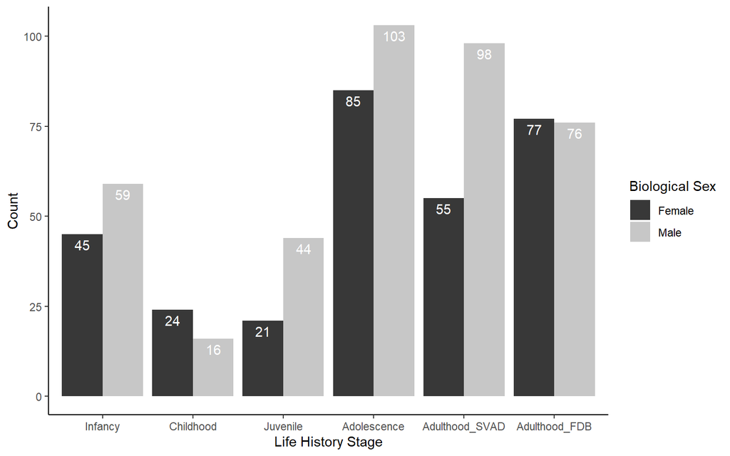

```r
joint_balanced %>% dplyr::select(Sex, Dev_LHS_2, GOL:FOB) %>% na.omit() %>% mutate(Dev_LHS_2 = fct_relevel(Dev_LHS_2, "infancy", "childhood", "juvenile", "adolescence", "adult_SVAD", "adult_FDB")) %>% ggplot(aes(x=Dev_LHS_2)) + geom_bar(aes(fill = Sex), position = "dodge") + geom_text(stat = "count", aes(label=after_stat(count),group=Sex), position = position_dodge(0.9), color="white", vjust=1.5) + labs(x="Life History Stage", y = "Count", fill= "Biological Sex") + scale_fill_manual(values = c("grey22", "grey78"), labels = c("Female","Male")) + theme(legend.position = c(.085, .935)) + scale_x_discrete(labels = c("infancy" = "Infancy", "childhood" = "Childhood", "juvenile" = "Juvenile", "adolescence" = "Adolescence", "adult_SVAD" = "Adulthood_SVAD", "adult_FDB" = "Adulthood_FDB")) + theme_classic()
```

```r
ggsave("Fig1_FINAL.png", units = "in", height = 5, width = 8)
```

## Figure 2

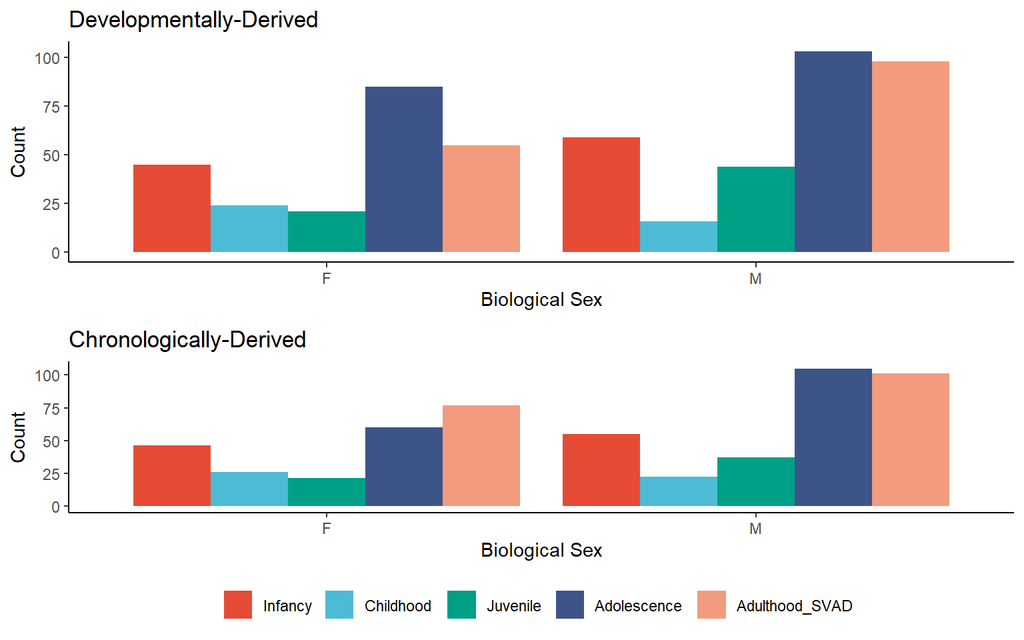

```r
a <- joint_balanced %>% filter(sample == "SVAD") %>% dplyr::select(Sex, Dev_LHS_2, GOL:FOB) %>% na.omit() %>% mutate(Dev_LHS_2 = fct_relevel(Dev_LHS_2, "infancy", "childhood", "juvenile", "adolescence", "adult_SVAD")) %>% ggplot(aes(x=Sex)) + geom_bar(aes(fill = Dev_LHS_2), position = "dodge") + labs(title = "Developmentally-Derived",x="Biological Sex", y = "Count") + scale_fill_npg(labels = c("infancy" = "Infancy", "childhood" = "Childhood", "juvenile" = "Juvenile", "adolescence" = "Adolescence", "adult_SVAD" = "Adulthood_SVAD")) + theme_classic() +theme(legend.position = "none") + theme(legend.title = element_blank())

b <- joint_balanced %>% filter(sample == "SVAD") %>% dplyr::select(Sex, Chron_LHS, GOL:FOB) %>% na.omit() %>% mutate(Chron_LHS = fct_relevel(Chron_LHS, "infancy", "childhood", "juvenile", "adolescence", "adult_SVAD")) %>% ggplot(aes(x=Sex)) + geom_bar(aes(fill = Chron_LHS), position = "dodge") + labs(title = "Chronologically-Derived",x="Biological Sex", y = "Count") + scale_fill_npg(labels = c("infancy" = "Infancy", "childhood" = "Childhood", "juvenile" = "Juvenile", "adolescence" = "Adolescence", "adult_SVAD" = "Adulthood_SVAD")) + theme_classic() +theme(legend.position = "bottom") + theme(legend.title = element_blank())

ggarrange(a,b, ncol = 1)
```

```r
ggsave("Fig2_FINAL.png", width = 8, height = 5, units = "in")
```

# Results + Discussion

All code necessary to reproduce Figures 3-8 and Tables 3-9 can be found in this sections.  
Note, all linear discriminant analyses are run in parallel for computational efficiency. This can be adjust based on user specifications and needs.

## Life History Stage Exploration

All life history models are fit with Linear Discriminant Analyses with validation completed using Leave-One-Out Cross-Validation.

### Model Fit - SVAD

```r
svad_lh__lda_dat <- joint_balanced %>% filter(sample == "SVAD") %>% dplyr::select(Dev_LHS_2, GOL:FOB) %>% na.omit() %>% mutate(across(GOL:FOB, scale), Dev_LHS_2 = factor(Dev_LHS_2, ordered = T, levels = c("infancy", "childhood", "juvenile", "adolescence", "adult_SVAD") ))

lda_svad_lh <- train(Dev_LHS_2 ~ ., data = svad_lh__lda_dat, method = "lda", trControl = trainControl(method = "LOOCV", allowParallel = T), priors = c(0.2,0.2,0.2,0.2,0.2))
```

### Model Summary - SVAD

```r
lda_svad_lh$finalModel
```

```
Call:
lda(x, grouping = y, priors = ..1)

Prior probabilities of groups:
    infancy   childhood    juvenile adolescence  adult_SVAD
 0.18909091  0.07272727  0.11818182  0.34181818  0.27818182

Group means:
                    GOL         NOL           BNL        BBH        XCB
infancy     -1.54734386 -1.56863819 -1.6413006224 -1.5942121 -1.1525451
childhood   -0.72300975 -0.75170010 -0.9149773813 -0.6179778 -0.2354961
juvenile    -0.01502681 -0.01059537 -0.0005080185  0.1086918  0.2615092
adolescence  0.49068727  0.50585151  0.5460318294  0.4757865  0.3380071
adult_SVAD   0.64425940  0.64571889  0.6841398515  0.6144075  0.3185692
                   WFB        ZYB         AUB         ASB         BPL
infancy     -1.4492817 -1.6335807 -1.64983850 -1.40482522 -1.57395520
childhood   -0.5384955 -0.9129353 -0.80874927 -0.41772647 -0.97861512
juvenile     0.2702778 -0.1423917  0.02304648  0.09503044 -0.09978698
adolescence  0.3919082  0.5715455  0.56829057  0.39691672  0.53950478
adult_SVAD   0.5295315  0.7072857  0.62481389  0.53603634  0.70519739
                   NPH       NLH_L        JUB         NLB      OBH_L      OBB_L
infancy     -1.6694368 -1.67533408 -1.5911677 -1.31123007 -1.3383319 -1.5080506
childhood   -0.7763268 -0.96196188 -0.9251522 -0.49734672 -0.4695720 -0.9151106
juvenile    -0.1396061 -0.06324402 -0.1474033  0.02870126 -0.1171497 -0.1088393
adolescence  0.5847302  0.61456184  0.5485639  0.37459241  0.4728009  0.4996932
adult_SVAD   0.6785595  0.66200297  0.7120178  0.54884210  0.5012912  0.6965615
                   DKB        FMB         EKB        FRC        PAC        OCC
infancy     -1.0020145 -1.5776307 -1.55980340 -1.5120927 -1.0727757 -1.2045209
childhood   -0.4722500 -0.8992781 -0.87901974 -0.6351160 -0.4671875 -0.2596737
juvenile     0.1661359 -0.0875331 -0.07647811  0.0358770  0.1941452 -0.2075309
adolescence  0.2864399  0.5184729  0.51723761  0.4753739  0.3197967  0.3318347
adult_SVAD   0.3820260  0.7075912  0.68699836  0.5945098  0.3759147  0.5670700
                   FOL         FOB
infancy     -0.9303126 -1.04758669
childhood   -0.1006861 -0.25768826
juvenile     0.2624612  0.05284138
adolescence  0.2181277  0.30309835
adult_SVAD   0.2791633  0.38457103

Coefficients of linear discriminants:
```

[output cut: 14 more lines]

```
NLB   -0.28232540 -0.32457642  0.55053319  0.22440203
OBH_L -0.07856381  0.10836486  0.25929057 -0.48713514
OBB_L  0.10263992  0.05579861 -0.46639728  1.44948192
DKB    0.03222537 -0.11958400 -0.17546532  0.29351499
FMB    0.35706849  0.58473871 -0.02249739  1.19104421
EKB    0.05737652 -0.27146084 -0.10160267 -1.71038731
FRC   -0.14629144  0.53303412 -0.26128416 -0.04433444
PAC   -0.34957217  0.32326488 -0.40278822 -0.50720856
OCC   -0.17955800  0.69112011  0.44772403 -0.24592106
FOL   -0.13410458 -0.25033564 -0.06049676  0.08335409
FOB   -0.09863822  0.02841377  0.15335508 -0.17908870

Proportion of trace:
   LD1    LD2    LD3    LD4
0.9438 0.0363 0.0159 0.0040
```

```r
lda_svad_lh_pred <- lda_svad_lh$pred
conf_matrix <- confusionMatrix(lda_svad_lh_pred$pred, lda_svad_lh_pred$obs)
```

### Table 3

```r
# Extract class means
class_means_svad <- lda_svad_lh$finalModel$means

# Compute the pooled covariance matrix from raw data
pooled_cov_svad_lh <- var(svad_lh__lda_dat[, colnames(class_means_svad)])  # Use only predictor variables

# Number of classes
num_classes <- nrow(class_means_svad)

# Compute Mahalanobis distance between centroids
mahal_dist_centroids_svad_lh <- matrix(NA, nrow = num_classes, ncol = num_classes)

for (i in 1:num_classes) {
  for (j in 1:num_classes) {
    mahal_dist_centroids_svad_lh[i, j] <- mahalanobis(
      class_means_svad[i, ],
      center = class_means_svad[j, ],
      cov = pooled_cov_svad_lh
    )
  }
}

# Convert to a named matrix
rownames(mahal_dist_centroids_svad_lh) <- colnames(mahal_dist_centroids_svad_lh) <- rownames(class_means_svad)

# print(mahal_dist_centroids)

mal_cent_svad_lh <- mahal_dist_centroids_svad_lh
mal_cent_svad_lh
```

```
             infancy childhood juvenile adolescence adult_SVAD
infancy     0.000000  3.078355 5.073144   5.5587212  5.9579483
childhood   3.078355  0.000000 3.734676   5.0323498  5.1564854
juvenile    5.073144  3.734676 0.000000   2.3302578  3.5835297
adolescence 5.558721  5.032350 2.330258   0.0000000  0.4891018
adult_SVAD  5.957948  5.156485 3.583530   0.4891018  0.0000000
```

```r
write.csv(mal_cent_svad_lh, "Table3.csv", row.names = T)
```

### Table 4

```r
print(conf_matrix$table)
```

```
             Reference
Prediction    infancy childhood juvenile adolescence adult_SVAD
  infancy          87         8        0           0          0
  childhood        17        31        8           0          0
  juvenile          0         1       45           3          3
  adolescence       0         0       11         128         81
  adult_SVAD        0         0        1          57         69
```

```r
write.csv(conf_matrix$table, "Table4.csv", row.names = T)
```

### Figure 3

```r
CVA_scores <- svad_lh__lda_dat %>% mutate(Dev_LHS_2 = factor(Dev_LHS_2)) %>% {as.matrix(dplyr::select(., rownames(lda_svad_lh$finalModel$scaling))) %*% lda_svad_lh$finalModel$scaling} %>% as.data.frame

CVA_scores$stage <- svad_lh__lda_dat %>% dplyr::select(Dev_LHS_2) %>% mutate(Dev_LHS_2 = factor(Dev_LHS_2, ordered = TRUE, levels = c("infancy", "childhood", "juvenile", "adolescence", "adult_SVAD"))) %>% pull(Dev_LHS_2)
```

```r
chi2 = qchisq(0.05,2, lower.tail=FALSE)

CIregions.mean.and.pop <-
  CVA_scores %>%
  group_by(stage) %>%
  summarize(CV1.mean = mean(LD1),
            CV2.mean = mean(LD2),
            mean.radii = sqrt(chi2/n()),
            popn.radii = sqrt(chi2))
```

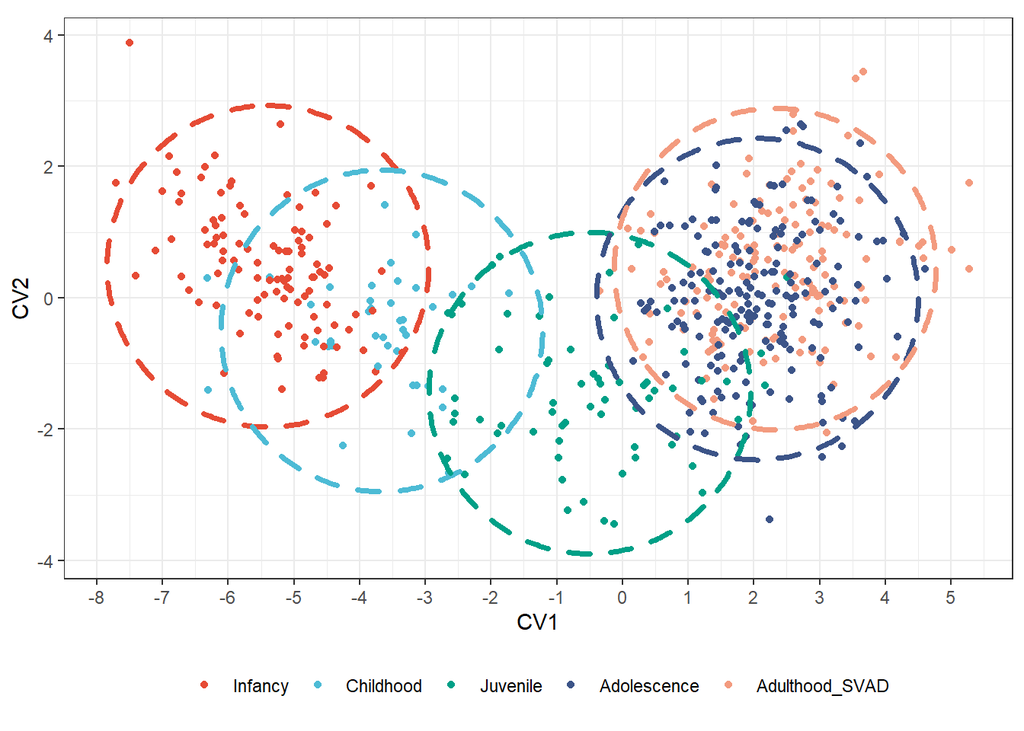

```r
ggplot() + geom_point(data = CVA_scores, mapping = aes(x = LD1, y = LD2, color = stage)) + labs(x = "CV1", y = "CV2") + coord_fixed(ratio=1) + geom_circle(data = CIregions.mean.and.pop, mapping = aes(x0=CV1.mean,y0=CV2.mean,r=popn.radii, color=stage), linetype = "dashed", inherit.aes = F, size = 1.25,show.legend = FALSE) + labs(x = "CV1",y = "CV2", color = "Life History Stage") + scale_x_continuous(breaks = seq(-10,7,1)) + scale_color_npg(labels = c("infancy" = "Infancy", "childhood" = "Childhood", "juvenile" = "Juvenile", "adolescence" = "Adolescence", "adult_SVAD" = "Adulthood_SVAD")) + theme_bw() + theme(legend.position = "bottom", legend.title = element_blank())
```

```r
ggsave("Fig3_FINAL.png", units = "in", height = 5, width = 8)
```

### Model Fit - SVAD + FDB

```r
comb_lh_lda_dat <- joint_balanced %>% dplyr::select(Dev_LHS_2, GOL:FOB) %>% na.omit() %>% mutate(across(GOL:FOB, scale), Dev_LHS_2 = factor(Dev_LHS_2, ordered = TRUE, levels = c("infancy", "childhood", "juvenile", "adolescence", "adult_SVAD", "adult_FDB")))

lda_comb_lh <- train(Dev_LHS_2 ~ ., data = comb_lh_lda_dat, method = "lda", trControl = trainControl(method = "LOOCV", allowParallel = T), priors = c(1/6,1/6,1/6,1/6,1/6))
```

### Table 6

```r
lda_comb_lh$finalModel
```

```
Call:
lda(x, grouping = y, priors = ..1)

Prior probabilities of groups:
    infancy   childhood    juvenile adolescence  adult_SVAD   adult_FDB
 0.14793741  0.05689900  0.09246088  0.26742532  0.21763869  0.21763869

Group means:
                   GOL        NOL        BNL          BBH         XCB
infancy     -1.7677247 -1.7943151 -1.8757481 -1.815139021 -1.23301724
childhood   -0.9037401 -0.9318179 -1.1054189 -0.777653686 -0.25855743
juvenile    -0.1617033 -0.1493832 -0.1355443 -0.005391243  0.26956231
adolescence  0.3683356  0.3958650  0.4441089  0.384735843  0.35084927
adult_SVAD   0.5292945  0.5435325  0.5905845  0.532054181  0.33019449
adult_FDB    0.5246701  0.4967863  0.4853140  0.434617048  0.02990274
                   WFB        ZYB         AUB         ASB        BPL        NPH
infancy     -1.6051156 -1.8715521 -1.87813053 -1.56655492 -1.7789313 -1.9194169
childhood   -0.6541489 -1.0931322 -0.95937111 -0.51996248 -1.1369250 -0.9603762
juvenile     0.1903044 -0.2608136 -0.05076337  0.02369895 -0.1892092 -0.2766518
adolescence  0.3173007  0.5103603  0.54483117  0.34378030  0.5001940  0.5011561
adult_SVAD   0.4609955  0.6569828  0.60657412  0.49128483  0.6788746  0.6019121
adult_FDB    0.3303486  0.3846634  0.27297999  0.27700982  0.2933345  0.4556005
                 NLH_L        JUB         NLB      OBH_L      OBB_L        DKB
infancy     -1.9282036 -1.8119579 -1.42440993 -1.4682139 -1.7387739 -1.0842934
childhood   -1.1621981 -1.0915613 -0.58416948 -0.5547950 -1.1019586 -0.5626248
juvenile    -0.1971719 -0.2503082 -0.04108577 -0.1842562 -0.2360263  0.0660054
adolescence  0.5306432  0.5024857  0.31600684  0.4360211  0.4175353  0.1844709
adult_SVAD   0.5815845  0.6792858  0.49589949  0.4659759  0.6289710  0.2785962
adult_FDB    0.4646662  0.3266540  0.25420967  0.2195845  0.4282572  0.3508196
                   FMB        EKB         FRC         PAC        OCC
infancy     -1.8024411 -1.7827710 -1.72258674 -1.19708554 -1.3415441
childhood   -1.0870061 -1.0768445 -0.79671223 -0.58458614 -0.3700277
juvenile    -0.2308868 -0.2446633 -0.08830647  0.08429402 -0.3164131
adolescence  0.4082468  0.3709795  0.37569551  0.21137950  0.2381765
adult_SVAD   0.6077033  0.5470099  0.50147414  0.26813798  0.4800516
adult_FDB    0.4981225  0.5944341  0.45360216  0.40285472  0.3703494
                    FOL         FOB
infancy     -1.05925256 -1.19928592
childhood   -0.22609355 -0.44725682
juvenile     0.13860002 -0.15161461
```

[output cut: 19 more lines]

```
NLB   -0.2767233864 -0.01170722  0.333010379 -0.53421310 -0.2517153
OBH_L -0.1611684043 -0.28128011 -0.091761235 -0.39734815  0.4205021
OBB_L -0.0007103667 -1.34654047 -0.531639416  0.14854997 -1.4388023
DKB   -0.0969630488 -0.46268057  0.003135414  0.11730733 -0.2568039
FMB    0.3530940933 -0.64710630 -0.885693273 -0.15719825 -1.1244058
EKB    0.3712717507  4.30809370  1.657556328  1.14024734  1.6334078
FRC   -0.0631616585  0.68772275 -0.432338588  0.20205861  0.1269486
PAC   -0.3965328192  0.27028303 -0.436729732  0.38616359  0.4723977
OCC   -0.1318674803  0.39585903 -0.676244643 -0.43959070  0.2364629
FOL   -0.2461575827  0.01304763  0.281444760  0.04842067 -0.0788508
FOB   -0.0041978528  0.40653085  0.058780368 -0.09146224  0.1018555

Proportion of trace:
   LD1    LD2    LD3    LD4    LD5
0.8599 0.0955 0.0282 0.0131 0.0033
```

```r
lda_comb_lh_pred <- lda_comb_lh$pred
conf_matrix <- confusionMatrix(lda_comb_lh_pred$pred, lda_comb_lh_pred$obs)
print(conf_matrix$table)
```

```
             Reference
Prediction    infancy childhood juvenile adolescence adult_SVAD adult_FDB
  infancy          90         7        0           0          0         0
  childhood        14        32        8           0          0         0
  juvenile          0         1       41           1          4         1
  adolescence       0         0       14         119         74        19
  adult_SVAD        0         0        1          49         54        10
  adult_FDB         0         0        1          19         21       123
```

```r
write.csv(conf_matrix$table, "Table6.csv", row.names = T)
```

### Table 5

```r
# Extract class means
class_means_comb <- lda_comb_lh$finalModel$means

# Compute the pooled covariance matrix from raw data
pooled_cov_comb_lh <- var(comb_lh_lda_dat[, colnames(class_means_comb)])  # Use only predictor variables

# Number of classes
num_classes <- nrow(class_means_comb)

# Compute Mahalanobis distance between centroids
mahal_dist_centroids_comb_lh <- matrix(NA, nrow = num_classes, ncol = num_classes)

for (i in 1:num_classes) {
  for (j in 1:num_classes) {
    mahal_dist_centroids_comb_lh[i, j] <- mahalanobis(
      class_means_comb[i, ],
      center = class_means_comb[j, ],
      cov = pooled_cov_comb_lh
    )
  }
}

# Convert to a named matrix
rownames(mahal_dist_centroids_comb_lh) <- colnames(mahal_dist_centroids_comb_lh) <- rownames(class_means_comb)

# print(mahal_dist_centroids)

mal_cent_comb_lh <- mahal_dist_centroids_comb_lh
mal_cent_comb_lh
```

```
             infancy childhood juvenile adolescence adult_SVAD adult_FDB
infancy     0.000000  3.275324 5.714514   6.7569574  7.1949707  7.472230
childhood   3.275324  0.000000 3.945258   5.6873525  5.8798476  6.430559
juvenile    5.714514  3.945258 0.000000   2.3877984  3.6340838  5.172027
adolescence 6.756957  5.687352 2.387798   0.0000000  0.4692488  3.090581
adult_SVAD  7.194971  5.879848 3.634084   0.4692488  0.0000000  3.053794
adult_FDB   7.472230  6.430559 5.172027   3.0905809  3.0537939  0.000000
```

```r
write.csv(mal_cent_comb_lh, "Table5.csv", row.names = T)
```

### Figure 4

```r
CVA_scores <- comb_lh_lda_dat %>% {as.matrix(dplyr::select(., rownames(lda_comb_lh$finalModel$scaling))) %*% lda_comb_lh$finalModel$scaling} %>% as.data.frame

CVA_scores$stage <- comb_lh_lda_dat %>% dplyr::select(Dev_LHS_2) %>% mutate(Dev_LHS_2 = factor(Dev_LHS_2, ordered = TRUE, levels = c("infancy", "childhood", "juvenile", "adolescence", "adult_SVAD", "adult_FDB"))) %>% pull(Dev_LHS_2)
```

```r
chi2 = qchisq(0.05,2, lower.tail=FALSE)

CIregions.mean.and.pop <-
  CVA_scores %>%
  group_by(stage) %>%
  summarize(CV1.mean = mean(LD1),
            CV2.mean = mean(LD2),
            mean.radii = sqrt(chi2/n()),
            popn.radii = sqrt(chi2))
```

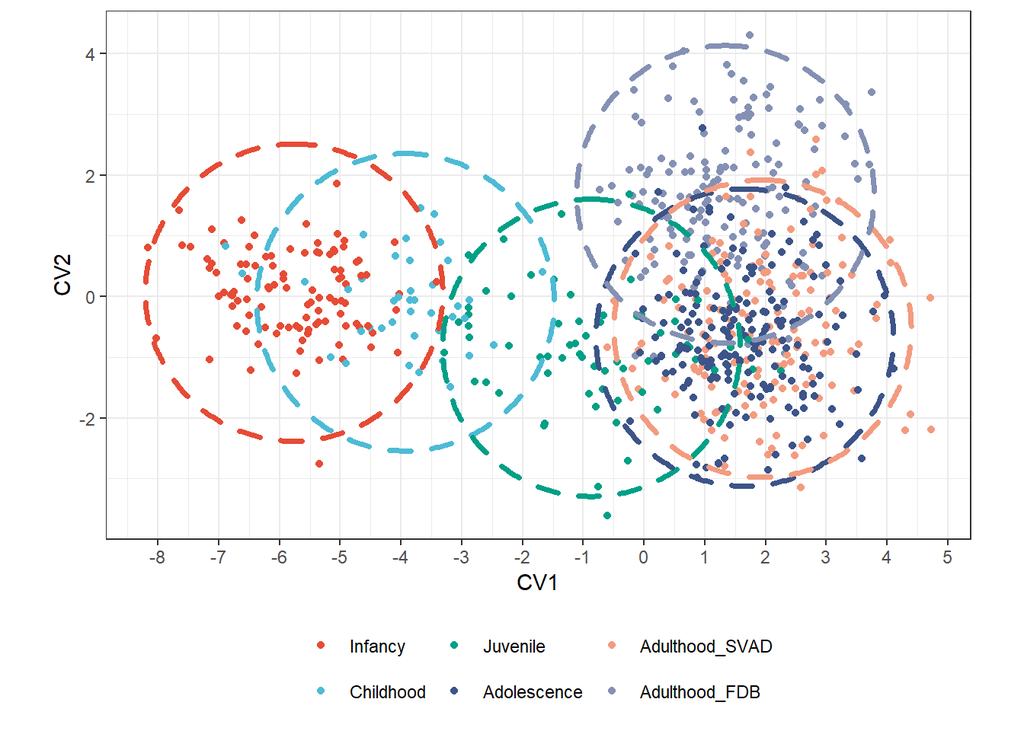

```r
ggplot() + geom_point(data = CVA_scores, mapping = aes(x = LD1, y = LD2, color = stage)) + labs(x = "CV1", y = "CV2") + coord_fixed(ratio=1) + geom_circle(data = CIregions.mean.and.pop, mapping = aes(x0=CV1.mean,y0=CV2.mean,r=popn.radii, color=stage), linetype = "dashed", inherit.aes = F, size = 1.25,show.legend = FALSE) + labs(x = "CV1",y = "CV2", color = "Life History Stage") + scale_x_continuous(breaks = seq(-10,5,1)) + scale_color_npg(labels = c("infancy" = "Infancy", "childhood" = "Childhood", "juvenile" = "Juvenile", "adolescence" = "Adolescence", "adult_SVAD" = "Adulthood_SVAD", "adult_FDB" = "Adulthood_FDB")) + theme_bw() + theme(legend.position = "bottom", legend.title = element_blank())
```

```r
ggsave("Fig4_FINAL.png", units = "in", width = 8, height = 5)
```

### Figure 8

```r
temp_dat <- joint_balanced %>% dplyr::select(medrec, Sex, Dev_LHS_2, GOL:FOB) %>% na.omit() %>% mutate(Dev_LHS_2 = factor(Dev_LHS_2, ordered = TRUE, levels = c("infancy", "childhood", "juvenile", "adolescence", "adult_SVAD", "adult_FDB")))

# Here I hard code the medrecs where M2 development is at least 'Root Complete'. This could also be done by combining datasets between craniometrics + ontogenetic variables and filtering.

temp_dat %<>% dplyr::select(1,2,3,4)
new <- cbind(temp_dat, CVA_scores)
m886 <- which(new$medrec == 886)
m916 <- which(new$medrec == 916)
m725 <- which(new$medrec == 725)
m618 <- which(new$medrec == 618)
m613 <- which(new$medrec == 613)
m312 <- which(new$medrec == 312)
m174 <- which(new$medrec == 174)
m883 <- which(new$medrec == 883)
m316 <- which(new$medrec == 316)
m919 <- which(new$medrec == 919)
```

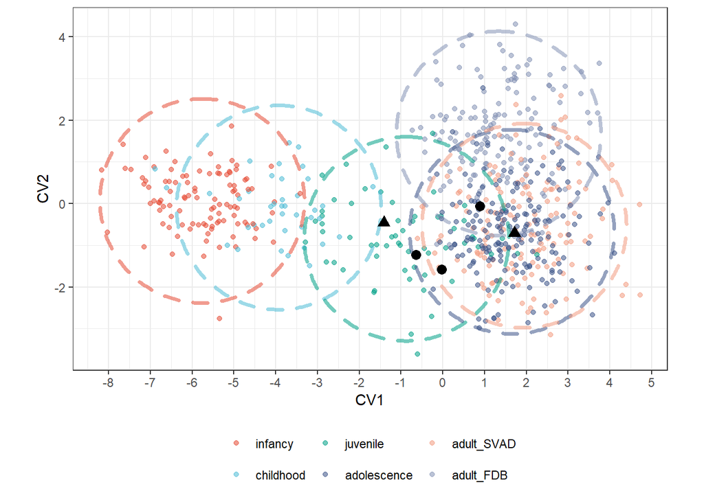

```r
ggplot() + geom_point(data = CVA_scores, mapping = aes(x = LD1, y = LD2, color = stage)) + coord_fixed(ratio=1) + geom_circle(data = CIregions.mean.and.pop, mapping = aes(x0=CV1.mean,y0=CV2.mean,r=popn.radii, color=stage), linetype = "dashed", inherit.aes = F, size = 1.25,show.legend = FALSE) + labs(x = "CV1",y = "CV2", color = "Life History Stage") + scale_x_continuous(breaks = seq(-10,5,1)) + scale_color_npg(alpha=0.55) + theme_bw() + theme(legend.position = "bottom", legend.title = element_blank()) + geom_point(new[c(m886,m916, m725),], mapping=aes(x = LD1, y = LD2), colour = "black", pch = 17, size=3) + geom_point(new[c(m618,m613,m312),], mapping=aes(x = LD1, y = LD2), colour = "black", size=3)
```

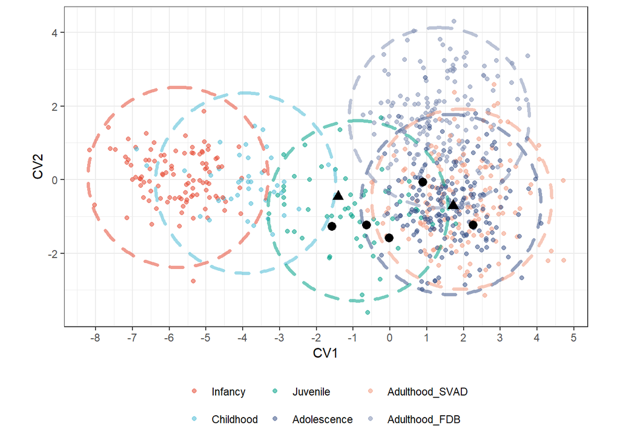

```r
ggplot() + geom_point(data = CVA_scores, mapping = aes(x = LD1, y = LD2, color = stage)) + coord_fixed(ratio=1) + geom_circle(data = CIregions.mean.and.pop, mapping = aes(x0=CV1.mean,y0=CV2.mean,r=popn.radii, color=stage), linetype = "dashed", inherit.aes = F, size = 1.25,show.legend = FALSE) + labs(x = "CV1",y = "CV2", color = "Life History Stage") + scale_x_continuous(breaks = seq(-10,5,1)) + scale_color_npg(labels = c("infancy" = "Infancy", "childhood" = "Childhood", "juvenile" = "Juvenile", "adolescence" = "Adolescence", "adult_SVAD" = "Adulthood_SVAD", "adult_FDB" = "Adulthood_FDB"), alpha =  0.55) + theme_bw() + theme(legend.position = "bottom", legend.title = element_blank()) + geom_point(new[c(m886,m916, m725,m174,m883),], mapping=aes(x = LD1, y = LD2), colour = "black", pch = 17, size=3) + geom_point(new[c(m618,m613,m312,m316,m919),], mapping=aes(x = LD1, y = LD2), colour = "black", size=3)
```

```r
ggsave("Figure8_FINAL.png", units = "in", width = 8, height = 5, bg = "white")
```

### Figure 7

```r
m2 <- svad %>% filter(m2 >= 11) %>% dplyr::select(medrec)
```

```r
m2_sub <- joint_balanced[joint_balanced$medrec %in% m2$medrec,]
```

```r
svad_sub2 <- m2_sub %>% dplyr::select(Sex,Dev_LHS_2, Chron_LHS) %>% droplevels() %>% mutate(Dev_LHS_2 = factor(Dev_LHS_2, ordered = TRUE, levels = c("juvenile", "adolescence", "adult_SVAD"), labels = c("Juvenile","Adolescence","Adulthood_SVAD")), Chron_LHS = factor(Chron_LHS, ordered = TRUE, levels = c("juvenile", "adolescence", "adult_SVAD"),labels = c("Juvenile","Adolescence","Adulthood_SVAD")))
```

```r
dev_lhs <- svad_sub2 %>% ggplot(aes(x = Dev_LHS_2, fill = Sex)) + geom_bar(position = "dodge") + scale_fill_manual(values = c("grey22", "grey78"), labels = c("Female","Male")) + xlab("Developmental LHS") + theme_minimal()

chron_lhs <- svad_sub2 %>% dplyr::select(Sex, Chron_LHS) %>% na.omit() %>% ggplot(aes(x = Chron_LHS, fill = Sex)) + geom_bar(position = "dodge") + scale_fill_manual(values = c("grey22", "grey78"), labels = c("Female","Male")) + xlab("Chronological LHS") + theme_minimal()
```

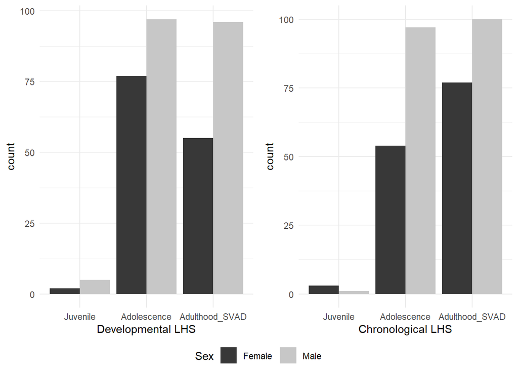

```r
ggarrange(dev_lhs, chron_lhs, ncol = 2, legend = "bottom", common.legend = T)
```

```r
ggsave("Figure7_FINAL.png", units = "in", width = 8, height = 5, bg = "white")
```

## Biological Sex Estimation

Figure 5 and Table 7-9 are a combination of values from each individual model below. There is no section labelled “Table 7” for example, but a user can reproduce the table values by running each individual model.  
All sex estimation models are fit with a forward step wise LDA algorithm and leave-one-out cross validation.

### Infancy

```r
infancy_dat <- joint_balanced %>% filter(sample == "SVAD", Dev_LHS_2 == "infancy") %>% dplyr::select(Sex,Age ,GOL:FOB) %>% na.omit() %>% mutate(across(GOL:FOB, scale), Sex = factor(Sex))
```

```r
## Stepwise model

lda_infancy <- train(Sex ~ ., data = infancy_dat, method = "stepLDA", trControl = trainControl(method = "LOOCV", allowParallel = TRUE), tuneGrid = data.frame(maxvar = 24, direction = "forward"))
```

```
correctness rate: 0.64091;  in: "PAC";  variables (1): PAC
correctness rate: 0.66182;  in: "WFB";  variables (2): PAC, WFB
correctness rate: 0.67273;  in: "ASB";  variables (3): PAC, WFB, ASB
correctness rate: 0.68182;  in: "FRC";  variables (4): PAC, WFB, ASB, FRC
correctness rate: 0.70091;  in: "AUB";  variables (5): PAC, WFB, ASB, FRC, AUB

 hr.elapsed min.elapsed sec.elapsed
       0.00        0.00        1.76
```

```r
lda_infancy$finalModel
```

```
method      : lda
final model : y ~ WFB + AUB + ASB + FRC + PAC
<environment: 0x0000022510a88a88>

correctness rate = 0.7009
```

```r
infancy_preds <- lda_infancy$pred
infancy_conf_matrix <- confusionMatrix(infancy_preds$pred, infancy_preds$obs)
infancy_conf_matrix
```

```
Confusion Matrix and Statistics

          Reference
Prediction  F  M
         F 16 16
         M 29 43

               Accuracy : 0.5673
                 95% CI : (0.4665, 0.6641)
    No Information Rate : 0.5673
    P-Value [Acc > NIR] : 0.54114

                  Kappa : 0.0874

 Mcnemar's Test P-Value : 0.07364

            Sensitivity : 0.3556
            Specificity : 0.7288
         Pos Pred Value : 0.5000
         Neg Pred Value : 0.5972
             Prevalence : 0.4327
         Detection Rate : 0.1538
   Detection Prevalence : 0.3077
      Balanced Accuracy : 0.5422

       'Positive' Class : F
```

```r
inf_accuracy <- infancy_conf_matrix$overall["Accuracy"]
print(infancy_conf_matrix$table)
```

```
          Reference
Prediction  F  M
         F 16 16
         M 29 43
```

### Childhood

```r
child_dat <- joint_balanced %>% filter(sample == "SVAD", Dev_LHS_2 == "childhood") %>% dplyr::select(Sex,Age, GOL:FOB) %>% na.omit() %>% mutate(across(GOL:FOB, scale), Sex = factor(Sex))
```

```r
## Stepwise model

lda_child <- train(Sex ~ ., data = child_dat, method = "stepLDA", trControl = trainControl(method = "LOOCV", allowParallel = TRUE), tuneGrid = data.frame(maxvar = 24, direction = "forward"))
```

```
correctness rate: 0.7;  in: "FOL";  variables (1): FOL
correctness rate: 0.775;  in: "OCC";  variables (2): FOL, OCC
correctness rate: 0.8;  in: "GOL";  variables (3): FOL, OCC, GOL
correctness rate: 0.8;  in: "BBH";  variables (4): FOL, OCC, GOL, BBH
correctness rate: 0.8;  in: "XCB";  variables (5): FOL, OCC, GOL, BBH, XCB
correctness rate: 0.8;  in: "BNL";  variables (6): FOL, OCC, GOL, BBH, XCB, BNL
correctness rate: 0.8;  in: "ZYB";  variables (7): FOL, OCC, GOL, BBH, XCB, BNL, ZYB
correctness rate: 0.825;  in: "BPL";  variables (8): FOL, OCC, GOL, BBH, XCB, BNL, ZYB, BPL
correctness rate: 0.85;  in: "NOL";  variables (9): FOL, OCC, GOL, BBH, XCB, BNL, ZYB, BPL, NOL
correctness rate: 0.85;  in: "NLB";  variables (10): FOL, OCC, GOL, BBH, XCB, BNL, ZYB, BPL, NOL, NLB

 hr.elapsed min.elapsed sec.elapsed
       0.00        0.00        2.25
```

```r
lda_child$finalModel
```

```
method      : lda
final model : y ~ GOL + NOL + BNL + BBH + XCB + ZYB + BPL + NLB + OCC + FOL
<environment: 0x000002250a13fd90>

correctness rate = 0.85
```

```r
child_preds <- lda_child$pred
child_conf_matrix <- confusionMatrix(child_preds$pred, child_preds$obs)
child_conf_matrix
```

```
Confusion Matrix and Statistics

          Reference
Prediction  F  M
         F 16  8
         M  8  8

               Accuracy : 0.6
                 95% CI : (0.4333, 0.7514)
    No Information Rate : 0.6
    P-Value [Acc > NIR] : 0.5681

                  Kappa : 0.1667

 Mcnemar's Test P-Value : 1.0000

            Sensitivity : 0.6667
            Specificity : 0.5000
         Pos Pred Value : 0.6667
         Neg Pred Value : 0.5000
             Prevalence : 0.6000
         Detection Rate : 0.4000
   Detection Prevalence : 0.6000
      Balanced Accuracy : 0.5833

       'Positive' Class : F
```

```r
child_accuracy <- child_conf_matrix$overall["Accuracy"]
print(child_conf_matrix$table)
```

```
          Reference
Prediction  F  M
         F 16  8
         M  8  8
```

### Juvenile

```r
juv_dat <- joint_balanced %>% filter(sample == "SVAD", Dev_LHS_2 == "juvenile") %>% dplyr::select(Sex,Age, GOL:FOB) %>% na.omit() %>% mutate(across(GOL:FOB, scale), Sex = factor(Sex))
```

```r
## Stepwise model

lda_juv <- train(Sex ~ ., data = juv_dat, method = "stepLDA", trControl = trainControl(method = "LOOCV", allowParallel = TRUE), tuneGrid = data.frame(maxvar = 24, direction = "forward"))
```

```
correctness rate: 0.69286;  in: "BNL";  variables (1): BNL
correctness rate: 0.72381;  in: "ZYB";  variables (2): BNL, ZYB
correctness rate: 0.7381;  in: "BPL";  variables (3): BNL, ZYB, BPL
correctness rate: 0.7381;  in: "AUB";  variables (4): BNL, ZYB, BPL, AUB

 hr.elapsed min.elapsed sec.elapsed
       0.00        0.00        1.19
```

```r
lda_juv$finalModel
```

```
method      : lda
final model : y ~ BNL + ZYB + AUB + BPL
<environment: 0x000002250ad202e0>

correctness rate = 0.7381
```

```r
juv_preds <- lda_juv$pred
juv_conf_matrix <- confusionMatrix(juv_preds$pred, juv_preds$obs)
juv_conf_matrix
```

```
Confusion Matrix and Statistics

          Reference
Prediction  F  M
         F  6  7
         M 15 37

               Accuracy : 0.6615
                 95% CI : (0.5335, 0.7743)
    No Information Rate : 0.6769
    P-Value [Acc > NIR] : 0.6593

                  Kappa : 0.1406

 Mcnemar's Test P-Value : 0.1356

            Sensitivity : 0.28571
            Specificity : 0.84091
         Pos Pred Value : 0.46154
         Neg Pred Value : 0.71154
             Prevalence : 0.32308
         Detection Rate : 0.09231
   Detection Prevalence : 0.20000
      Balanced Accuracy : 0.56331

       'Positive' Class : F
```

```r
juv_accuracy <- juv_conf_matrix$overall["Accuracy"]
print(juv_conf_matrix$table)
```

```
          Reference
Prediction  F  M
         F  6  7
         M 15 37
```

### Adolescence

```r
adol_dat <- joint_balanced %>% filter(sample == "SVAD", Dev_LHS_2 == "adolescence") %>% dplyr::select(Sex,Age, GOL:FOB) %>% na.omit() %>% mutate(across(GOL:FOB, scale), Sex = factor(Sex))
```

```r
## Stepwise model

lda_adol <- train(Sex ~ ., data = adol_dat, method = "stepLDA", trControl = trainControl(method = "LOOCV", allowParallel = TRUE), tuneGrid = data.frame(maxvar = 24, direction = "forward"))
```

```
correctness rate: 0.81374;  in: "BNL";  variables (1): BNL
correctness rate: 0.83538;  in: "FRC";  variables (2): BNL, FRC
correctness rate: 0.86199;  in: "ZYB";  variables (3): BNL, FRC, ZYB
correctness rate: 0.86784;  in: "OBH_L";  variables (4): BNL, FRC, ZYB, OBH_L
correctness rate: 0.87281;  in: "ASB";  variables (5): BNL, FRC, ZYB, OBH_L, ASB
correctness rate: 0.88363;  in: "DKB";  variables (6): BNL, FRC, ZYB, OBH_L, ASB, DKB
correctness rate: 0.8886;  in: "FOL";  variables (7): BNL, FRC, ZYB, OBH_L, ASB, DKB, FOL
correctness rate: 0.8886;  in: "XCB";  variables (8): BNL, FRC, ZYB, OBH_L, ASB, DKB, FOL, XCB
correctness rate: 0.8886;  in: "WFB";  variables (9): BNL, FRC, ZYB, OBH_L, ASB, DKB, FOL, XCB, WFB

 hr.elapsed min.elapsed sec.elapsed
       0.00        0.00        2.64
```

```r
lda_adol$finalModel
```

```
method      : lda
final model : y ~ BNL + XCB + WFB + ZYB + ASB + OBH_L + DKB + FRC + FOL
<environment: 0x00000225092c3e38>

correctness rate = 0.8886
```

```r
adol_preds <- lda_adol$pred
adol_conf_matrix <- confusionMatrix(adol_preds$pred, adol_preds$obs)
adol_conf_matrix
```

```
Confusion Matrix and Statistics

          Reference
Prediction  F  M
         F 71 18
         M 14 85

               Accuracy : 0.8298
                 95% CI : (0.7683, 0.8806)
    No Information Rate : 0.5479
    P-Value [Acc > NIR] : 2.89e-16

                  Kappa : 0.6578

 Mcnemar's Test P-Value : 0.5959

            Sensitivity : 0.8353
            Specificity : 0.8252
         Pos Pred Value : 0.7978
         Neg Pred Value : 0.8586
             Prevalence : 0.4521
         Detection Rate : 0.3777
   Detection Prevalence : 0.4734
      Balanced Accuracy : 0.8303

       'Positive' Class : F
```

```r
adol_accuracy <- adol_conf_matrix$overall["Accuracy"]
print(adol_conf_matrix$table)
```

```
          Reference
Prediction  F  M
         F 71 18
         M 14 85
```

```r
#### Classification Errors Code!
preds_adols <- lda_adol$pred

lh <- joint_balanced %>% filter(sample == "SVAD", Dev_LHS_2 %in% c("adolescence")) %>% dplyr::select(Age,Sex, Dev_LHS_2 ,GOL:FOB) %>% na.omit()

preds_adols$lh <- lh$Dev_LHS_2
preds_adols$age <- lh$Age
preds_adols$Sex <- lh$Sex

preds_adols %<>% mutate(correct = ifelse(pred == obs, "correct", "wrong"))

preds_adols %>% group_by(obs, pred, lh) %>% summarise(count = n())
```

```
# A tibble: 4 × 4
# Groups:   obs, pred [4]
  obs   pred  lh          count
  <fct> <fct> <chr>       <int>
1 F     F     adolescence    71
2 F     M     adolescence    14
3 M     F     adolescence    18
4 M     M     adolescence    85
```

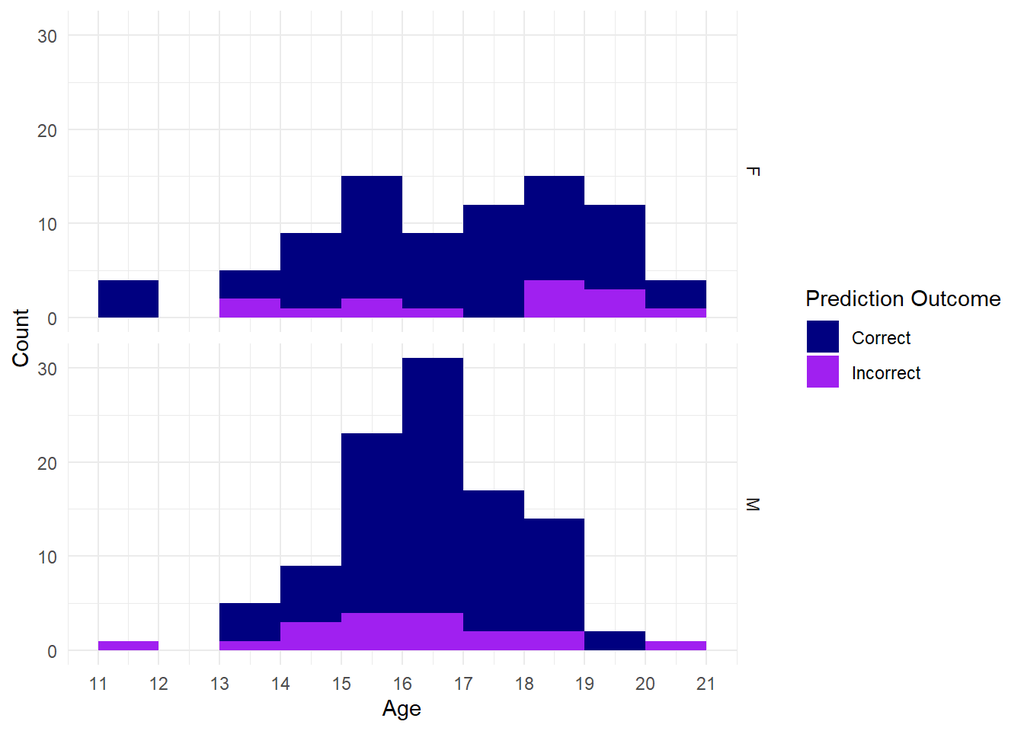

```r
## Counts
adol_count <- ggplot(preds_adols, aes(x=age ,fill=correct)) + geom_histogram(boundary = 11, binwidth = 1) +  facet_grid(Sex ~ .) + scale_fill_manual(values=c("navy", "purple"), labels = c("Correct", "Incorrect")) + labs(fill = "Prediction Outcome") + scale_x_continuous(breaks = seq(11,21,1)) + xlab("Age") + ylab("Count") + theme_minimal()

adol_count2 <- ggplot(preds_adols, aes(x=age ,fill=correct)) + geom_histogram(boundary = 11, binwidth = 1) +  facet_grid(Sex ~ .) + scale_fill_manual(values=c("navy", "purple"), labels = c("Correct", "Incorrect")) + labs(fill = "Prediction Outcome") + scale_x_continuous(breaks = seq(11,21,1)) + xlab("Age") + ylab("Count") + guides(fill = "none") + theme_minimal()

adol_count
```

```r
# ggsave("adol_misclass_count.png", plot = adol_count ,units = "in", width = 8, height = 5)
```

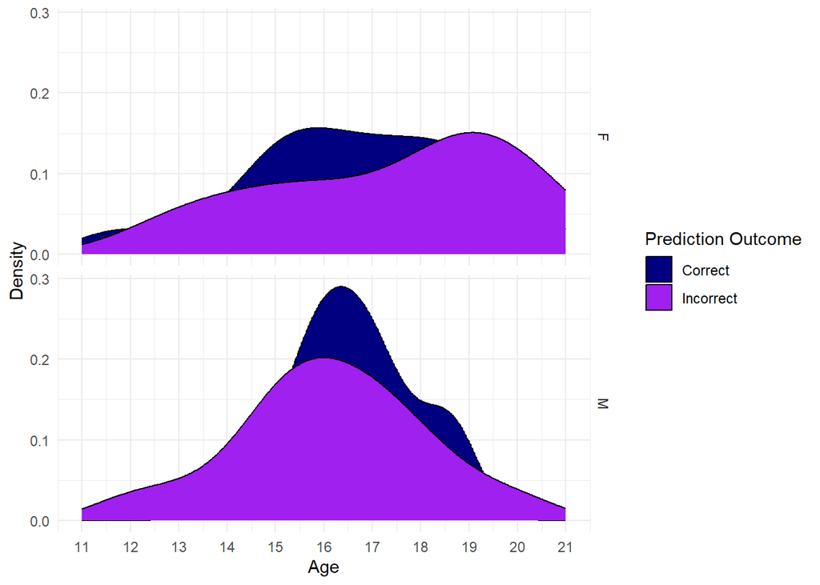

```r
## Density
adol_density <- ggplot(preds_adols, aes(x=age ,fill=correct)) + geom_density() + facet_grid(Sex ~ .) + scale_fill_manual(values=c("navy", "purple"), labels = c("Correct", "Incorrect")) + labs(fill = "Prediction Outcome")  + scale_x_continuous(breaks = seq(11,21,1), limits = c(11,21)) + xlab("Age") + ylab("Density") + theme_minimal()

adol_density
```

```r
# ggsave("adol_misclass_density.png", plot = adol_density ,units = "in", width = 8, height = 5)
```

### SVAD Adults

```r
svad_adult_dat <- joint_balanced %>% filter(sample == "SVAD", Dev_LHS_2 == "adult_SVAD") %>% dplyr::select(Sex,Age, GOL:FOB) %>% na.omit() %>% mutate(across(GOL:FOB, scale), Sex = factor(Sex))
```

```r
## Stepwise model

lda_svad_adult <- train(Sex ~ ., data = svad_adult_dat, method = "stepLDA", trControl = trainControl(method = "LOOCV", allowParallel = TRUE), tuneGrid = data.frame(maxvar = 24, direction = "forward"))
```

```
correctness rate: 0.82833;  in: "ZYB";  variables (1): ZYB
correctness rate: 0.86875;  in: "BNL";  variables (2): ZYB, BNL
correctness rate: 0.89542;  in: "GOL";  variables (3): ZYB, BNL, GOL
correctness rate: 0.92083;  in: "DKB";  variables (4): ZYB, BNL, GOL, DKB
correctness rate: 0.9275;  in: "ASB";  variables (5): ZYB, BNL, GOL, DKB, ASB
correctness rate: 0.9275;  in: "BBH";  variables (6): ZYB, BNL, GOL, DKB, ASB, BBH
correctness rate: 0.92833;  in: "FRC";  variables (7): ZYB, BNL, GOL, DKB, ASB, BBH, FRC

 hr.elapsed min.elapsed sec.elapsed
       0.00        0.00        2.14
```

```r
lda_svad_adult$finalModel
```

```
method      : lda
final model : y ~ GOL + BNL + BBH + ZYB + ASB + DKB + FRC
<environment: 0x000002250e706858>

correctness rate = 0.9283
```

```r
svad_adult_preds <- lda_svad_adult$pred
svad_adult_conf_matrix <- confusionMatrix(svad_adult_preds$pred, svad_adult_preds$obs)
svad_adult_conf_matrix
```

```
Confusion Matrix and Statistics

          Reference
Prediction  F  M
         F 46  8
         M  9 90

               Accuracy : 0.8889
                 95% CI : (0.8281, 0.9339)
    No Information Rate : 0.6405
    P-Value [Acc > NIR] : 2.688e-12

                  Kappa : 0.7578

 Mcnemar's Test P-Value : 1

            Sensitivity : 0.8364
            Specificity : 0.9184
         Pos Pred Value : 0.8519
         Neg Pred Value : 0.9091
             Prevalence : 0.3595
         Detection Rate : 0.3007
   Detection Prevalence : 0.3529
      Balanced Accuracy : 0.8774

       'Positive' Class : F
```

```r
svad_adult_accuracy <- svad_adult_conf_matrix$overall["Accuracy"]
print(svad_adult_conf_matrix$table)
```

```
          Reference
Prediction  F  M
         F 46  8
         M  9 90
```

```r
#### Classification Errors Code!
preds_svad_adult <- lda_svad_adult$pred

lh <- joint_balanced %>% filter(sample == "SVAD", Dev_LHS_2 %in% c("adult_SVAD")) %>% dplyr::select(Age,Sex, Dev_LHS_2 ,GOL:FOB) %>% na.omit()

preds_svad_adult$lh <- lh$Dev_LHS_2
preds_svad_adult$age <- lh$Age
preds_svad_adult$Sex <- lh$Sex

preds_svad_adult %<>% mutate(correct = ifelse(pred == obs, "correct", "wrong"))

preds_svad_adult %>% group_by(obs, pred, lh) %>% summarise(count = n())
```

```
# A tibble: 4 × 4
# Groups:   obs, pred [4]
  obs   pred  lh         count
  <fct> <fct> <chr>      <int>
1 F     F     adult_SVAD    46
2 F     M     adult_SVAD     9
3 M     F     adult_SVAD     8
4 M     M     adult_SVAD    90
```

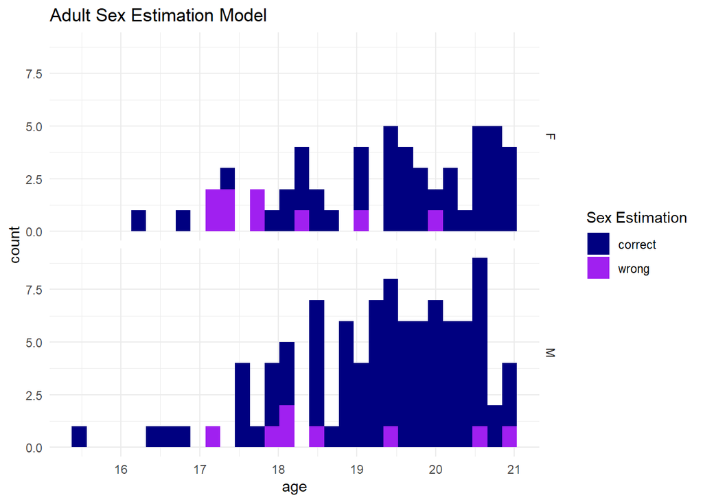

```r
ggplot(preds_svad_adult, aes(x=age, fill=correct)) + geom_histogram() + theme_minimal() + facet_grid(Sex ~ .) + scale_fill_manual(values=c("navy", "purple")) + labs(fill = "Sex Estimation", title="Adult Sex Estimation Model")
```

### SVAD Adolescence and Adults

```r
svad_old_dat <- joint_balanced %>% filter(sample == "SVAD", Dev_LHS_2 %in% c("adolescence", "adult_SVAD")) %>% dplyr::select(Sex, GOL:FOB) %>% na.omit() %>% mutate(across(GOL:FOB, scale), Sex = factor(Sex))
```

```r
## Stepwise model

lda_svad_old <- train(Sex ~ ., data = svad_old_dat, method = "stepLDA", trControl = trainControl(method = "LOOCV", allowParallel = TRUE), tuneGrid = data.frame(maxvar = 24, direction = "forward"))
```

```
correctness rate: 0.80664;  in: "BNL";  variables (1): BNL
correctness rate: 0.8416;  in: "ZYB";  variables (2): BNL, ZYB
correctness rate: 0.86807;  in: "FRC";  variables (3): BNL, ZYB, FRC
correctness rate: 0.88269;  in: "NLH_L";  variables (4): BNL, ZYB, FRC, NLH_L
correctness rate: 0.89437;  in: "NLB";  variables (5): BNL, ZYB, FRC, NLH_L, NLB
correctness rate: 0.89731;  in: "XCB";  variables (6): BNL, ZYB, FRC, NLH_L, NLB, XCB
correctness rate: 0.89731;  in: "BPL";  variables (7): BNL, ZYB, FRC, NLH_L, NLB, XCB, BPL

 hr.elapsed min.elapsed sec.elapsed
       0.00        0.00        2.65
```

```r
lda_svad_old$finalModel
```

```
method      : lda
final model : y ~ BNL + XCB + ZYB + BPL + NLH_L + NLB + FRC
<environment: 0x000002250762d038>

correctness rate = 0.8973
```

```r
svad_old_preds <- lda_svad_old$pred
svad_old_conf_matrix <- confusionMatrix(svad_old_preds$pred, svad_old_preds$obs)
svad_old_conf_matrix
```

```
Confusion Matrix and Statistics

          Reference
Prediction   F   M
         F 118  21
         M  22 180

               Accuracy : 0.8739
                 95% CI : (0.8339, 0.9072)
    No Information Rate : 0.5894
    P-Value [Acc > NIR] : <2e-16

                  Kappa : 0.7392

 Mcnemar's Test P-Value : 1

            Sensitivity : 0.8429
            Specificity : 0.8955
         Pos Pred Value : 0.8489
         Neg Pred Value : 0.8911
             Prevalence : 0.4106
         Detection Rate : 0.3460
   Detection Prevalence : 0.4076
      Balanced Accuracy : 0.8692

       'Positive' Class : F
```

```r
svad_old_accuracy <- svad_old_conf_matrix$overall["Accuracy"]
print(svad_old_conf_matrix$table)
```

```
          Reference
Prediction   F   M
         F 118  21
         M  22 180
```

```r
#### Classification Errors Code!
preds_svad_old <- lda_svad_old$pred

lh <- joint_balanced %>% filter(sample == "SVAD", Dev_LHS_2 %in% c("adolescence", "adult_SVAD")) %>% dplyr::select(Age,Sex, Dev_LHS_2 ,GOL:FOB) %>% na.omit()

preds_svad_old$lh <- lh$Dev_LHS_2
preds_svad_old$age <- lh$Age
preds_svad_old$Sex <- lh$Sex

preds_svad_old %<>% mutate(correct = ifelse(pred == obs, "correct", "wrong"))

preds_svad_old %>% group_by(obs, pred, lh) %>% summarise(count = n())
```

```
# A tibble: 8 × 4
# Groups:   obs, pred [4]
  obs   pred  lh          count
  <fct> <fct> <chr>       <int>
1 F     F     adolescence    72
2 F     F     adult_SVAD     46
3 F     M     adolescence    13
4 F     M     adult_SVAD      9
5 M     F     adolescence    15
6 M     F     adult_SVAD      6
7 M     M     adolescence    88
8 M     M     adult_SVAD     92
```

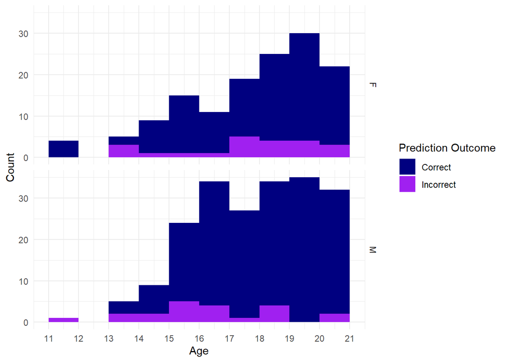

```r
## Count
adol_adult_count <- ggplot(preds_svad_old, aes(x=age, fill=correct)) + geom_histogram(boundary = 11, binwidth = 1) + theme_minimal() + facet_grid(Sex ~ .) + scale_fill_manual(values=c("navy", "purple"), labels = c("Correct", "Incorrect")) + labs(fill = "Prediction Outcome") + scale_x_continuous(breaks = seq(11,21,1), limits = c(11,21)) + xlab("Age") + ylab("Count")

adol_adult_count2 <- ggplot(preds_svad_old, aes(x=age, fill=correct)) + geom_histogram(boundary = 11, binwidth = 1) + theme_minimal() + facet_grid(Sex ~ .) + scale_fill_manual(values=c("navy", "purple"), labels = c("Correct", "Incorrect")) + labs(fill = "Prediction Outcome") + scale_x_continuous(breaks = seq(11,21,1), limits = c(11,21)) + xlab("Age") + ylab("Count") + guides(fill = "none")

adol_adult_count
```

```r
# ggsave("adol_adult_misclass_count.png", plot = adol_adult_count, units = "in", width = 8, height = 5)
```

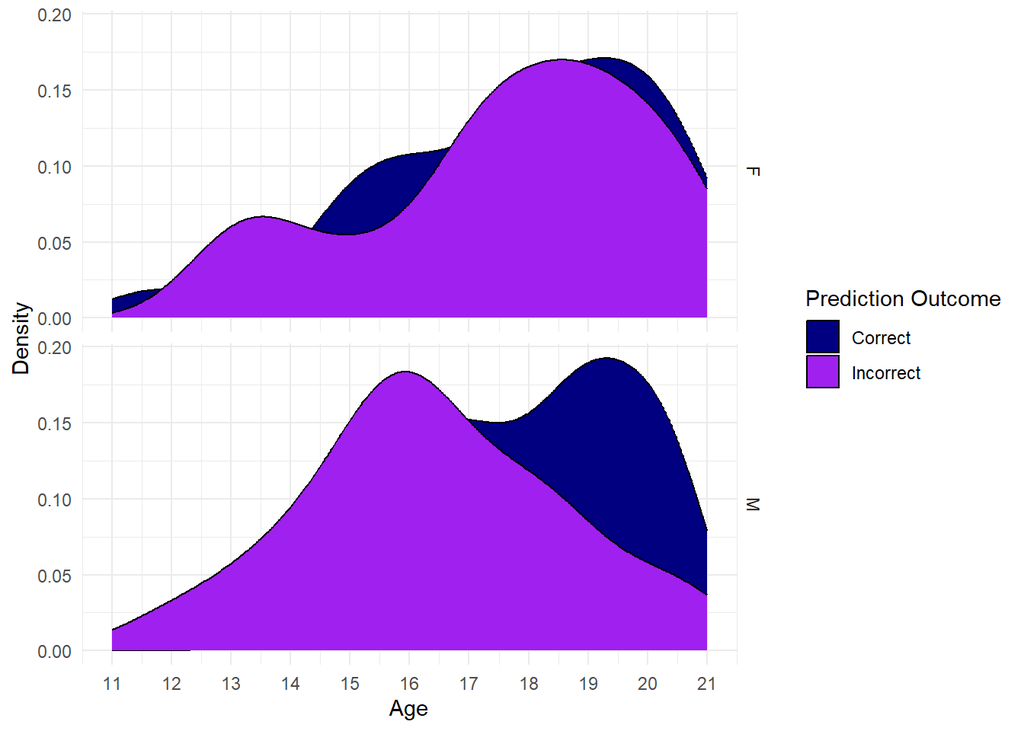

```r
## Density
adol_adult_density <- ggplot(preds_svad_old, aes(x=age, fill=correct)) + geom_density() + theme_minimal() + facet_grid(Sex ~ .) + scale_fill_manual(values=c("navy", "purple"),labels = c("Correct", "Incorrect")) + labs(fill = "Prediction Outcome") + scale_x_continuous(breaks = seq(11,21,1),limits = c(11,21)) + xlab("Age") + ylab("Density")

adol_adult_density2 <- ggplot(preds_svad_old, aes(x=age, fill=correct)) + geom_density() + theme_minimal() + facet_grid(Sex ~ .) + scale_fill_manual(values=c("navy", "purple"),labels = c("Correct", "Incorrect")) + labs(fill = "Prediction Outcome") + scale_x_continuous(breaks = seq(11,21,1),limits = c(11,21)) + xlab("Age") + ylab("Density") + guides(fill = "none")

adol_adult_density
```

```r
# ggsave("adol_adult_misclass_density.png", plot = adol_adult_density, units = "in", width = 8, height = 5)
```

### SVAD All

```r
svad_all_dat <- joint_balanced %>% filter(sample == "SVAD") %>% dplyr::select(Sex, GOL:FOB) %>% na.omit() %>% mutate(across(GOL:FOB, scale), Sex = factor(Sex))

svad_all_dat2 <- joint_balanced %>% filter(sample == "SVAD") %>% dplyr::select(Sex, GOL:FOB, Age, Dev_LHS_2) %>% na.omit() %>% mutate(across(GOL:FOB, scale), Sex = factor(Sex))
```

```r
## Stepwise model

lda_svad_all <- train(Sex ~ ., data = svad_all_dat, method = "stepLDA", trControl = trainControl(method = "LOOCV", allowParallel = TRUE), tuneGrid = data.frame(maxvar = 24, direction = "forward"))
```

```
correctness rate: 0.64545;  in: "FOL";  variables (1): FOL
correctness rate: 0.66;  in: "PAC";  variables (2): FOL, PAC
correctness rate: 0.67455;  in: "OBH_L";  variables (3): FOL, PAC, OBH_L
correctness rate: 0.70727;  in: "FRC";  variables (4): FOL, PAC, OBH_L, FRC
correctness rate: 0.70727;  in: "NLH_L";  variables (5): FOL, PAC, OBH_L, FRC, NLH_L

 hr.elapsed min.elapsed sec.elapsed
       0.00        0.00        2.55
```

```r
lda_svad_all$finalModel
```

```
method      : lda
final model : y ~ NLH_L + OBH_L + FRC + PAC + FOL
<environment: 0x000002250be86c10>

correctness rate = 0.7073
```

```r
svad_all_preds <- lda_svad_all$pred
svad_all_conf_matrix <- confusionMatrix(svad_all_preds$pred, svad_all_preds$obs)
svad_all_conf_matrix
```

```
Confusion Matrix and Statistics

          Reference
Prediction   F   M
         F 109  59
         M 121 261

               Accuracy : 0.6727
                 95% CI : (0.6318, 0.7118)
    No Information Rate : 0.5818
    P-Value [Acc > NIR] : 7.351e-06

                  Kappa : 0.3009

 Mcnemar's Test P-Value : 5.450e-06

            Sensitivity : 0.4739
            Specificity : 0.8156
         Pos Pred Value : 0.6488
         Neg Pred Value : 0.6832
             Prevalence : 0.4182
         Detection Rate : 0.1982
   Detection Prevalence : 0.3055
      Balanced Accuracy : 0.6448

       'Positive' Class : F
```

```r
svad_all_accuracy <- svad_all_conf_matrix$overall["Accuracy"]
print(svad_all_conf_matrix$table)
```

```
          Reference
Prediction   F   M
         F 109  59
         M 121 261
```

```r
svad_all_preds$age <- svad_all_dat2$Age
svad_all_preds$Sex <- svad_all_dat2$Sex

svad_all_preds %<>% mutate(correct = ifelse(pred == obs, "correct", "wrong"))
```

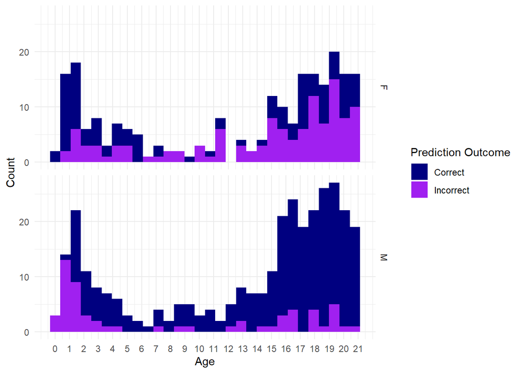

```r
svad_all_count <- ggplot(svad_all_preds, aes(x=age, fill=correct)) + geom_histogram() + theme_minimal() + facet_grid(Sex ~ .) + scale_fill_manual(values=c("navy", "purple"), labels = c("Correct", "Incorrect")) + labs(fill = "Prediction Outcome") + scale_x_continuous(breaks = seq(0,21,1)) + xlab("Age") + ylab("Count")

svad_all_count2 <- ggplot(svad_all_preds, aes(x=age, fill=correct)) + geom_histogram(boundary = 0) + theme_minimal() + facet_grid(Sex ~ .) + scale_fill_manual(values=c("navy", "purple"), labels = c("Correct", "Incorrect")) + labs(fill = "Prediction Outcome") + scale_x_continuous(breaks = seq(0,21,1), limits = c(0,21)) + xlab("Age") + ylab("Count") + guides(fill = "none")

svad_all_count
```

```r
# ggsave("svad_all_missclass_count.png", plot = svad_all_count, units = "in", width = 8, height = 5)
```

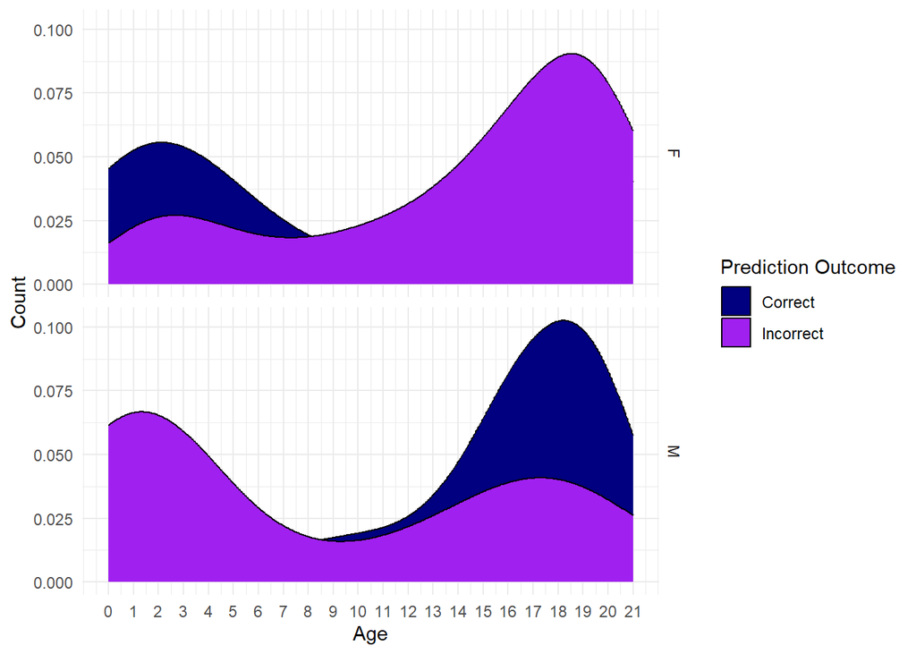

```r
svad_all_density <- ggplot(svad_all_preds, aes(x=age, fill=correct)) + geom_density() + theme_minimal() + facet_grid(Sex ~ .) + scale_fill_manual(values=c("navy", "purple"), labels = c("Correct", "Incorrect")) + labs(fill = "Prediction Outcome") + scale_x_continuous(breaks = seq(0,21,1), limits = c(0,21)) + xlab("Age") + ylab("Count")

svad_all_density
```

```r
# ggsave("svad_all_missclass_density.png", plot = svad_all_density, units = "in", width = 8, height = 5)
```

```r
combined_svad <- svad_all_count2 / svad_all_density + plot_layout(guides = "collect") + plot_annotation(tag_levels = 'A') & theme(legend.position = "bottom")

# ggsave(filename = "SVAD_all_misclass_combined.png", plot = combined_svad, units = "in", height = 9, width = 6)
```

### FDB Adults

```r
fdb_dat <- joint_balanced %>% filter(sample == "FDB") %>% dplyr::select(Sex, GOL:FOB) %>% na.omit() %>% mutate(across(GOL:FOB, scale), Sex = factor(Sex))
```

```r
## Stepwise model

lda_fdb <- train(Sex ~ ., data = fdb_dat, method = "stepLDA", trControl = trainControl(method = "LOOCV", allowParallel = TRUE), tuneGrid = data.frame(maxvar = 24, direction = "forward"))
```

```
correctness rate: 0.83083;  in: "ZYB";  variables (1): ZYB
correctness rate: 0.87667;  in: "BNL";  variables (2): ZYB, BNL
correctness rate: 0.88958;  in: "NOL";  variables (3): ZYB, BNL, NOL
correctness rate: 0.89583;  in: "GOL";  variables (4): ZYB, BNL, NOL, GOL
correctness rate: 0.90917;  in: "WFB";  variables (5): ZYB, BNL, NOL, GOL, WFB
correctness rate: 0.92167;  in: "BBH";  variables (6): ZYB, BNL, NOL, GOL, WFB, BBH
correctness rate: 0.93458;  in: "FOL";  variables (7): ZYB, BNL, NOL, GOL, WFB, BBH, FOL
correctness rate: 0.93458;  in: "DKB";  variables (8): ZYB, BNL, NOL, GOL, WFB, BBH, FOL, DKB

 hr.elapsed min.elapsed sec.elapsed
       0.00        0.00        2.36
```

```r
lda_fdb$finalModel
```

```
method      : lda
final model : y ~ GOL + NOL + BNL + BBH + WFB + ZYB + DKB + FOL
<environment: 0x000002250aa472a8>

correctness rate = 0.9346
```

```r
fdb_preds <- lda_fdb$pred
fdb_conf_matrix <- confusionMatrix(fdb_preds$pred, fdb_preds$obs)
fdb_conf_matrix
```

```
Confusion Matrix and Statistics

          Reference
Prediction  F  M
         F 67 10
         M 10 66

               Accuracy : 0.8693
                 95% CI : (0.8054, 0.9183)
    No Information Rate : 0.5033
    P-Value [Acc > NIR] : <2e-16

                  Kappa : 0.7386

 Mcnemar's Test P-Value : 1

            Sensitivity : 0.8701
            Specificity : 0.8684
         Pos Pred Value : 0.8701
         Neg Pred Value : 0.8684
             Prevalence : 0.5033
         Detection Rate : 0.4379
   Detection Prevalence : 0.5033
      Balanced Accuracy : 0.8693

       'Positive' Class : F
```

```r
fdb_accuracy <- fdb_conf_matrix$overall["Accuracy"]
print(fdb_conf_matrix$table)
```

```
          Reference
Prediction  F  M
         F 67 10
         M 10 66
```

### FDB Adults + SVAD Adolescence & Adults

```r
svad_fdb_dat <- joint_balanced %>% filter(Dev_LHS_2 %in% c("adolescence", "adult_SVAD", "adult_FDB")) %>% dplyr::select(Sex, GOL:FOB) %>% na.omit() %>% mutate(across(GOL:FOB, scale), Sex = factor(Sex))
```

```r
## Stepwise model

lda_svad_fdb <- train(Sex ~ ., data = svad_fdb_dat, method = "stepLDA", trControl = trainControl(method = "LOOCV", allowParallel = TRUE), tuneGrid = data.frame(maxvar = 24, direction = "forward"))
```

```
correctness rate: 0.79759;  in: "ZYB";  variables (1): ZYB
correctness rate: 0.84841;  in: "BNL";  variables (2): ZYB, BNL
correctness rate: 0.87657;  in: "GOL";  variables (3): ZYB, BNL, GOL
correctness rate: 0.88669;  in: "EKB";  variables (4): ZYB, BNL, GOL, EKB
correctness rate: 0.88878;  in: "OBB_L";  variables (5): ZYB, BNL, GOL, EKB, OBB_L
correctness rate: 0.89282;  in: "NLB";  variables (6): ZYB, BNL, GOL, EKB, OBB_L, NLB
correctness rate: 0.89482;  in: "FMB";  variables (7): ZYB, BNL, GOL, EKB, OBB_L, NLB, FMB

 hr.elapsed min.elapsed sec.elapsed
       0.00        0.00        2.98
```

```r
lda_svad_fdb$finalModel
```

```
method      : lda
final model : y ~ GOL + BNL + ZYB + NLB + OBB_L + FMB + EKB
<environment: 0x000002250b324f20>

correctness rate = 0.8948
```

```r
svad_fdb_preds <- lda_svad_fdb$pred
svad_fdb_conf_matrix <- confusionMatrix(svad_fdb_preds$pred, svad_fdb_preds$obs)
svad_fdb_conf_matrix
```

```
Confusion Matrix and Statistics

          Reference
Prediction   F   M
         F 186  31
         M  31 246

               Accuracy : 0.8745
                 95% CI : (0.842, 0.9024)
    No Information Rate : 0.5607
    P-Value [Acc > NIR] : <2e-16

                  Kappa : 0.7452

 Mcnemar's Test P-Value : 1

            Sensitivity : 0.8571
            Specificity : 0.8881
         Pos Pred Value : 0.8571
         Neg Pred Value : 0.8881
             Prevalence : 0.4393
         Detection Rate : 0.3765
   Detection Prevalence : 0.4393
      Balanced Accuracy : 0.8726

       'Positive' Class : F
```

```r
svad_fdb_accuracy <- svad_fdb_conf_matrix$overall["Accuracy"]
print(svad_fdb_conf_matrix$table)
```

```
          Reference
Prediction   F   M
         F 186  31
         M  31 246
```

### Figure 6

[figure not shown]

```r
combined <- adol_count2 / adol_density / adol_adult_count2 / adol_adult_density2 + plot_layout(guides = "collect") + plot_annotation(tag_levels = 'A') & theme(legend.position = "bottom")

combined
```

```r
ggsave(filename = "Figure6_FINAL.png", plot = combined, units = "in", height = 10, width = 7.5, bg = "white")
```

### Figure 5

```r
sex_acc <- tibble(
  Model = c("SVAD ALL","INF", "CHILD", "JUV", "ADOL", "ADULT", "ADOL + ADULT", "FDB", "FDB + SVAD" ),
    Accuracy = c(svad_all_accuracy, inf_accuracy, child_accuracy, juv_accuracy, adol_accuracy, svad_adult_accuracy, svad_old_accuracy, fdb_accuracy, svad_fdb_accuracy )
)

sex_acc$Model <- factor(sex_acc$Model, ordered = T, levels = c("SVAD ALL", "INF", "CHILD", "JUV", "ADOL", "ADULT", "ADOL + ADULT", "FDB", "FDB + SVAD"))
```

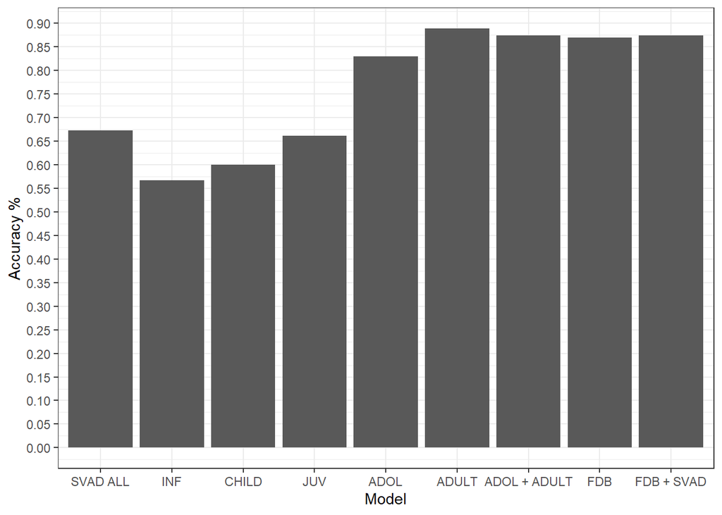

```r
ggplot(sex_acc, aes(x=Model,y=Accuracy)) + geom_col() + labs(x="Model", y = "Accuracy %") + scale_y_continuous(breaks = seq(0.0,.95,0.05)) + theme_bw()
```

```r
ggsave("Fig5_V2.png", units = "in", width = 8, height = 5, bg = "white")
```

# Postscript

```r
stopCluster(cl)
registerDoSEQ()  # Return to sequential processing
```

```r
version
```

```
               _
platform       x86_64-w64-mingw32
arch           x86_64
os             mingw32
crt            ucrt
system         x86_64, mingw32
status
major          4
minor          5.1
year           2025
month          06
day            13
svn rev        88306
language       R
version.string R version 4.5.1 (2025-06-13 ucrt)
nickname       Great Square Root
```

##################################END###########################################